# hw06_NAKANO-Katsuya

中野克哉

6月1日

# 問1

ベクトルを、デフォルトが昇順（小さい順）として並べ替える関数のR言語アルゴリズムは以下に示される。

```r
my_quicksort <-
  function (x, descending=FALSE) {
    # ベクトルを昇順または降順で並べかえるための関数
    # arg : x（ベクトル）
    #        descending (降順で並べかえる否か）
    # return: vec = 並び替えられたx

    if (length(x) <= 1) return(x) #xの長さが1ならば、その値をそのまま返す

   #長さが2以上のときは以下の作業をする
    ax = sample(x,1)  #xから無作為にひとつ取り出し、それを軸要素とする

    #xについて以下３つの作業をし、vecに整理
    #xのうち、axより小さいものはすべて左側にして、さらにそれらに同様のクイックソート(my_quicksort(x[x < ax])
    #xのうち、axと同じ値をすべて真ん中に（x[x == ax]）
    #xのうち、axより大きいものはすべて右側にして、さらにそれらに同様のクイックソート(my_quicksort(x[x > ax])
    vec<- c(my_quicksort(x[x < ax]), x[x == ax], my_quicksort(x[x > ax]))

    #もし引数descending（降順）がTRUEならば、上で整理したvecの順を逆にする
    if(descending==TRUE) vec<-rev(vec)

    return(vec)
  }
```

実際に値を並べえてみる。

```r
#xを[-100,100]の一様分布からランダムに取り出した長さ10のベクトルとする
#ちなみに、()でくくると値が瞬時に確認できる
(x <- runif(10, min = -100, max = 100))
```

```
##  [1]  46.11844  17.05532 -34.52866  11.99942  82.22075  87.47618  79.64761
##  [8]  61.23331  71.49133 -58.16847
```

10個取り出せた。

これらを昇順（小さい順）で並べ替えてみる。

```r
#昇順で並べ替えられたxを確認する
(x_rearranged_a <- my_quicksort(x, descending = FALSE))
```

```
##  [1] -58.16847 -34.52866  11.99942  17.05532  46.11844  61.23331  71.49133
##  [8]  79.64761  82.22075  87.47618
```

正しく並べ替えられた。

続いて、引数を変えて降順（大きい順）で並べ替えてみる。

```r
#降順で並べ替えられたxを確認する
(x_rearranged_d <- my_quicksort(x, descending = TRUE))
```

```
##  [1]  87.47618  82.22075  79.64761  71.49133  61.23331  46.11844  17.05532
##  [8]  11.99942 -34.52866 -58.16847
```

正しく動いているようである。

# 問2

以下に示されたような階乗の計算をするR言語アルゴリズムを示す。

$$n!=n(n-1)(n-2)...1$$
$$0!=1$$

```r
my_fact <- function(n) {
  # 階乗を計算する関数
  # arg: n = 非負の整数
  # return: nの階乗

  # 負値の入力に備える
  if (n < 0) stop(message = "n は非負かつ整数でお願いします")

  # 小数の入力に備える
  if (n != round(n)) stop(message = "n は非負かつ整数でお願いします")


  output_n <- 1
  if (n > 0) { # n > 0 の場合のみ実行
    for (i in 1:n) {
      output_n <- output_n * i
    }
  }
  return(output_n)
}
```

ここで、$n=5$を計算してみる。

```r
my_fact(5)
```

```
## [1] 120
```

正しく動いているようである。

# 問3

以下に示されたような組み合わせの計算をするR言語アルゴリズムを示す。
$$\binom{n}{k}=\dfrac{n!}{k!(n-k)!}$$

```r
my_comb <- function(n,k) {
  # 組み合わせを計算する関数
  # arg: n, k= 非負の整数
  # return: nからkを取り出す組み合わせ

  #組み合わせはnの階乗、kの階乗、(n-k)の階乗でできている。
  #それぞれを作り、最後に掛け合わせる。


  #まず、nの階乗をつくる
  # 負値の入力に備える
  if (n < 0) stop(message = "n は非負かつ整数でお願いします")

  # 小数の入力に備える
  if (n != round(n)) stop(message = "n は非負かつ整数でお願いします")

  output_n <- 1
  if (n > 0) { # n > 0 の場合のみ実行
    for (i in 1:n) {
      output_n <- output_n * i
    }
  }


  #次にkの階乗をつくる
  # 負値の入力に備える
  if (k < 0) stop(message = "k は非負かつ整数でお願いします")

  # 小数の入力に備える
  if (k != round(k)) stop(message = "k は非負かつ整数でお願いします")

  output_k <- 1
  if (k > 0) { # n > 0 の場合のみ実行
    for (j in 1:k) { #iは使ってるのでここではj
      output_k <- output_k * j
    }
  }


  #最後に(n-k)の階乗をつくる
  output_nk <- 1

  m<-n-k #n-kまで掛け合わせてほしいが、n-kをダイレクトにfor()に入れるとエラーが出てしまうのでこうした。

  if( n-k >0){
    for (l in 1:m) { #i,jは使ったし、kも使ってるので、lにする
      output_nk <- output_nk * l
    }
  }

  if( n-k < 0)stop(message = "n-k は非負でお願いします")

  #最後にそれぞれを組み合わせの公式に合わせて掛け合わせる
  output <- output_n/(output_k*output_nk)


  return(output)
}
```

ここで、$n=5$、$k=3$のときを考える。

```r
my_comb(5,3)
```

```
## [1] 10
```

正しく動いているようである。

# 問4

以下に示されたような二項分布の確率質量の計算をするR言語アルゴリズムを示す。
$$f(x)=\binom{n}{x}p^x(1-p)^{n-x}$$

```r
my_bin <- function(n,x,p) {
  # 二項分布の確率室用を計算する関数
  # arg: n, k = 非負の整数、pは[0,1]
  # return: 確率pの二項分布の確率質量

  # 負値の入力に備える
  if (n < 0) stop(message = "n は非負かつ整数でお願いします")

  # 小数の入力に備える
  if (n != round(n)) stop(message = "n は非負かつ整数でお願いします")

  output_n <- 1
  if (n > 0) { # n > 0 の場合のみ実行
    for (i in 1:n) {
      output_n <- output_n * i
    }
  }



  # 負値の入力に備える
  if (x < 0) stop(message = "x は非負かつ整数でお願いします")

  # 小数の入力に備える
  if (x != round(x)) stop(message = "x は非負かつ整数でお願いします")

  output_x <- 1
  if (x > 0) { # n > 0 の場合のみ実行
    for (j in 1:x) {
      output_x <- output_x * j
    }
  }

  output_nx <- 1

  q<-n-x #問4と同じくn-xだとfor()の中でエラーが出てしまうことに加え、ここではkではなくxを引いているので、一応mではなくqを使う


  if( n-x >0){
    for (l in 1:q) {
      output_nx <- output_nx * l
    }
  }

  if( n-x < 0)stop(message = "n-x は非負でお願いします")


  #まず組み合わせの公式に合わせて各階乗を掛け合わせる
  output1 <- output_n/(output_x*output_nx)

  #最後に、確率質量を導出する公式に合わせる
  output2 <- output1*p^x*(1-p)^q

  return(output2)
}
```

ここで、$n=5$、$k=3$、$p=0.5$のときを考える。

```r
my_bin(5,3,0.5)
```

```
## [1] 0.3125
```

正しく動いているようである。

# 問5

問4の確率質量を各nについて計算し、図示する。確率pは、0.5と0.8とする。

## $n=2$について

```r
#
ProbabilityMass<-numeric(length=0) #これから生成する確率質量(Probability mass)を保存する場所をつくる
for( x in 0:2){ #以下の作業がxが0のときから指定されたnのときまで繰り返される
z<-my_bin(2,x,0.5) #xの値が変わるごとに生成された確率質量をzにいれる
ProbabilityMass<-append(ProbabilityMass,z) #生成された確率質量の値を保存していく
}
ProbabilityMass #保存された確率質量を確認する
```

```
## [1] 0.25 0.50 0.25
```

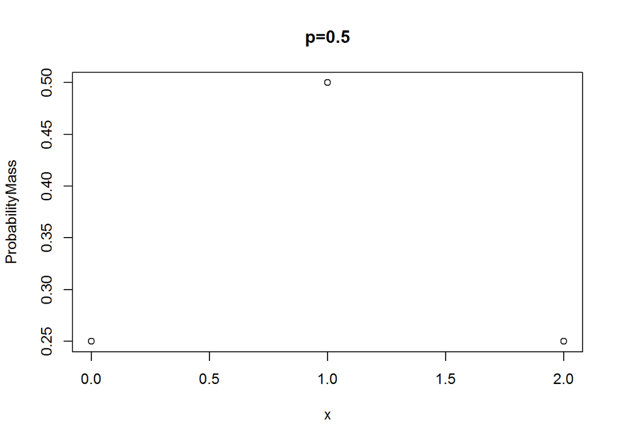

```r
x<-c(0:2) #これから図示するxの範囲を指定する
plot(x,ProbabilityMass,main="p=0.5") #図示
```

```r
ProbabilityMass<-numeric(length=0) #これから生成する確率質量(Probability mass)を保存する場所をつくる
for( x in 0:2){ #以下の作業がxが0のときから指定されたnのときまで繰り返される
z<-my_bin(2,x,0.8) #xの値が変わるごとに生成された確率質量をzにいれる
ProbabilityMass<-append(ProbabilityMass,z) #生成された確率質量の値を保存していく
}
ProbabilityMass #保存された確率質量を確認する
```

```
## [1] 0.04 0.32 0.64
```

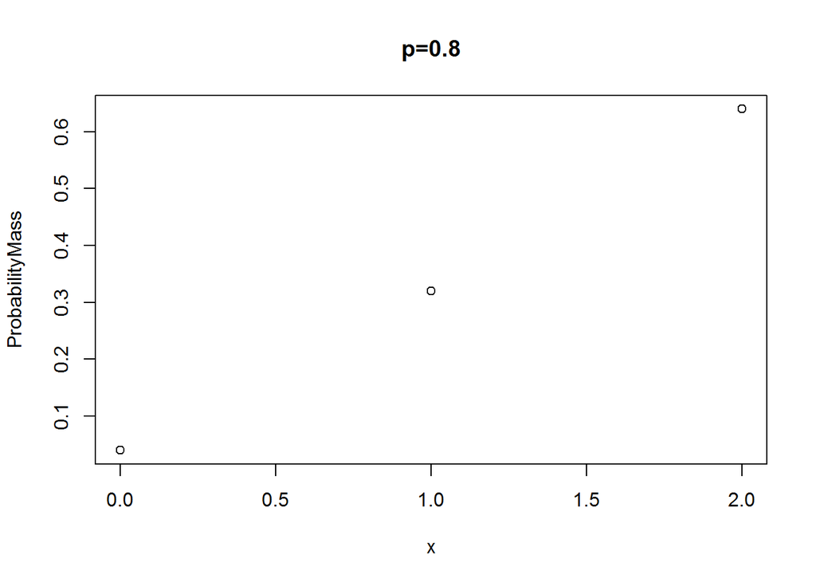

```r
x<-c(0:2) #これから図示するxの範囲を指定する
plot(x,ProbabilityMass,main="p=0.8") #図示
```

## $n=3$について

```r
ProbabilityMass<-numeric(length=0) #これから生成する確率質量(Probability mass)を保存する場所をつくる
for( x in 0:3){ #以下の作業がxが0のときから指定されたnのときまで繰り返される
z<-my_bin(3,x,0.5) #xの値が変わるごとに生成された確率質量をzにいれる
ProbabilityMass<-append(ProbabilityMass,z) #生成された確率質量の値を保存していく
}
ProbabilityMass #保存された確率質量を確認する
```

```
## [1] 0.125 0.375 0.375 0.125
```

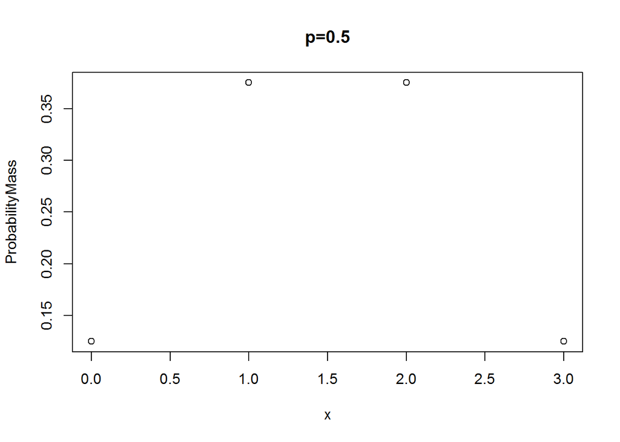

```r
x<-c(0:3) #これから図示するxの範囲を指定する
plot(x,ProbabilityMass,main="p=0.5") #図示
```

```r
ProbabilityMass<-numeric(length=0) #これから生成する確率質量(Probability mass)を保存する場所をつくる
for( x in 0:3){ #以下の作業がxが0のときから指定されたnのときまで繰り返される
z<-my_bin(3,x,0.8) #xの値が変わるごとに生成された確率質量をzにいれる
ProbabilityMass<-append(ProbabilityMass,z) #生成された確率質量の値を保存していく
}
ProbabilityMass #保存された確率質量を確認する
```

```
## [1] 0.008 0.096 0.384 0.512
```

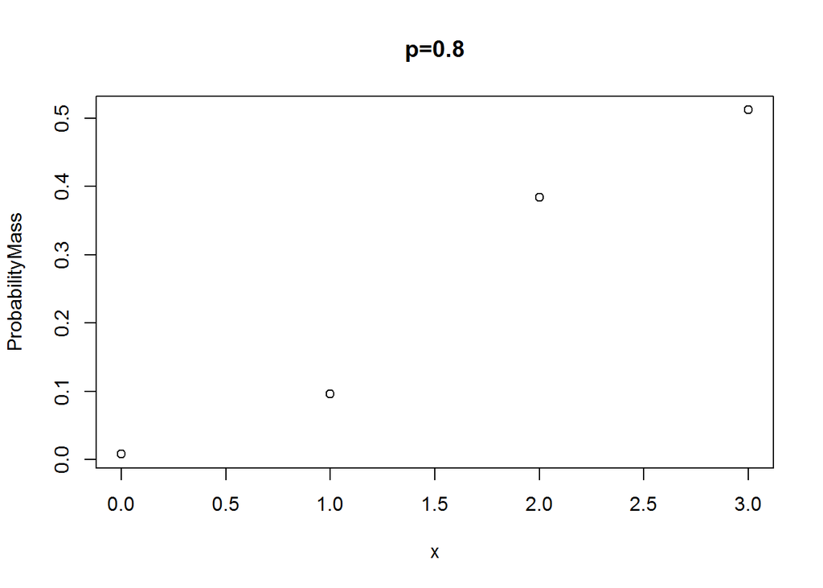

```r
x<-c(0:3) #これから図示するxの範囲を指定する
plot(x,ProbabilityMass,main="p=0.8") #図示
```

## $n=5$について

```r
ProbabilityMass<-numeric(length=0) #これから生成する確率質量(Probability mass)を保存する場所をつくる
for( x in 0:5){ #以下の作業がxが0のときから指定されたnのときまで繰り返される
z<-my_bin(5,x,0.5) #xの値が変わるごとに生成された確率質量をzにいれる
ProbabilityMass<-append(ProbabilityMass,z) #生成された確率質量の値を保存していく
}
ProbabilityMass #保存された確率質量を確認する
```

```
## [1] 0.03125 0.15625 0.31250 0.31250 0.15625 0.03125
```

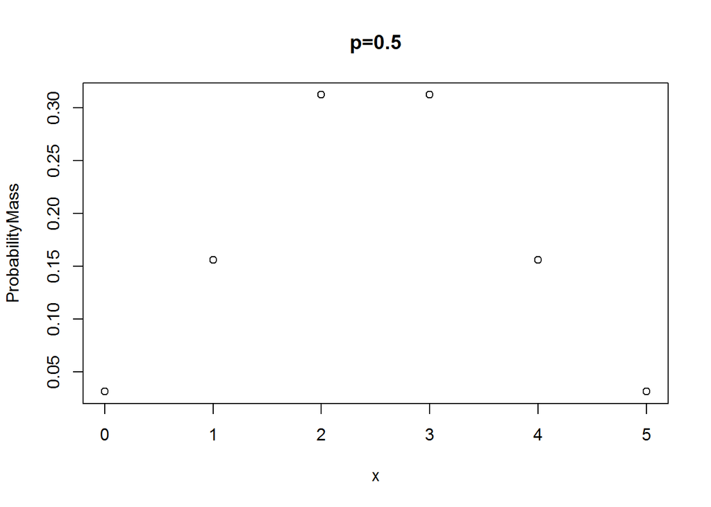

```r
x<-c(0:5) #これから図示するxの範囲を指定する
plot(x,ProbabilityMass,main="p=0.5") #図示
```

```r
ProbabilityMass<-numeric(length=0) #これから生成する確率質量(Probability mass)を保存する場所をつくる
for( x in 0:5){ #以下の作業がxが0のときから指定されたnのときまで繰り返される
z<-my_bin(5,x,0.8) #xの値が変わるごとに生成された確率質量をzにいれる
ProbabilityMass<-append(ProbabilityMass,z) #生成された確率質量の値を保存していく
}
ProbabilityMass #保存された確率質量を確認する
```

```
## [1] 0.00032 0.00640 0.05120 0.20480 0.40960 0.32768
```

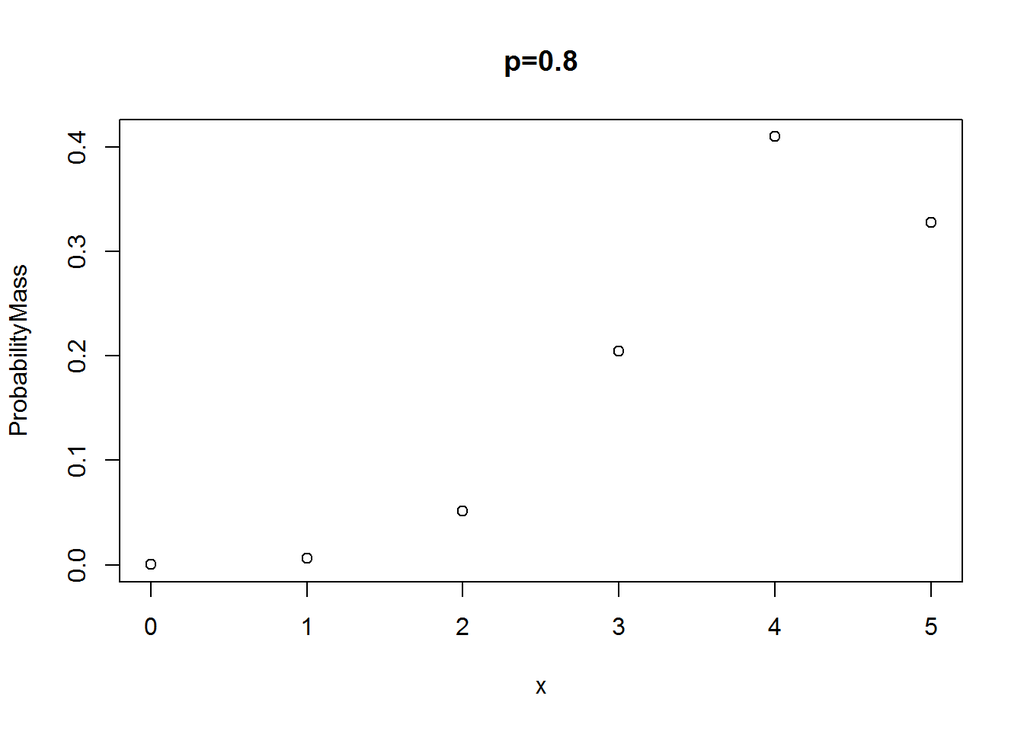

```r
x<-c(0:5) #これから図示するxの範囲を指定する
plot(x,ProbabilityMass,main="p=0.8") #図示
```

## $n=10$について

```r
ProbabilityMass<-numeric(length=0) #これから生成する確率質量(Probability mass)を保存する場所をつくる
for( x in 0:10){ #以下の作業がxが0のときから指定されたnのときまで繰り返される
z<-my_bin(10,x,0.5) #xの値が変わるごとに生成された確率質量をzにいれる
ProbabilityMass<-append(ProbabilityMass,z) #生成された確率質量の値を保存していく
}
ProbabilityMass #保存された確率質量を確認する
```

```
##  [1] 0.0009765625 0.0097656250 0.0439453125 0.1171875000 0.2050781250
##  [6] 0.2460937500 0.2050781250 0.1171875000 0.0439453125 0.0097656250
## [11] 0.0009765625
```

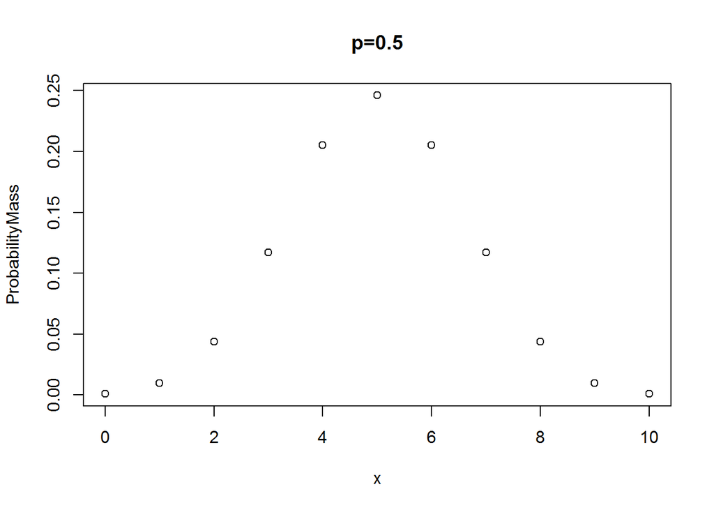

```r
x<-c(0:10) #これから図示するxの範囲を指定する
plot(x,ProbabilityMass,main="p=0.5") #図示
```

```r
ProbabilityMass<-numeric(length=0) #これから生成する確率質量(Probability mass)を保存する場所をつくる
for( x in 0:10){ #以下の作業がxが0のときから指定されたnのときまで繰り返される
z<-my_bin(10,x,0.8) #xの値が変わるごとに生成された確率質量をzにいれる
ProbabilityMass<-append(ProbabilityMass,z) #生成された確率質量の値を保存していく
}
ProbabilityMass #保存された確率質量を確認する
```

```
##  [1] 0.0000001024 0.0000040960 0.0000737280 0.0007864320 0.0055050240
##  [6] 0.0264241152 0.0880803840 0.2013265920 0.3019898880 0.2684354560
## [11] 0.1073741824
```

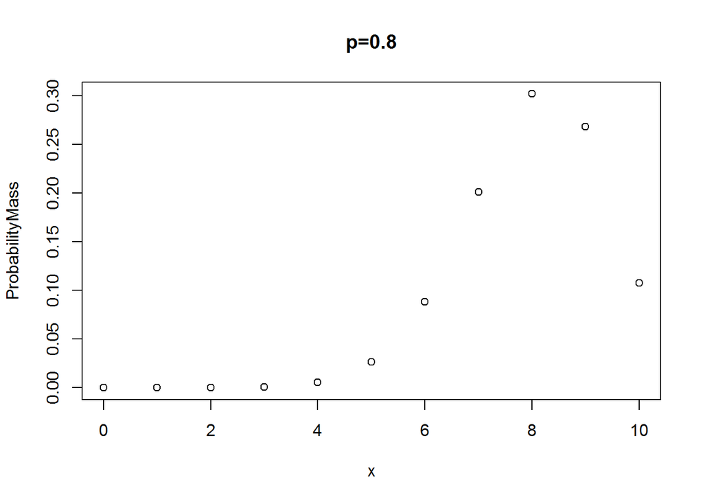

```r
x<-c(0:10) #これから図示するxの範囲を指定する
plot(x,ProbabilityMass,main="p=0.8") #図示
```